# IS 670 Lab 2: Data Exploration

## Part 1: Pokemon Data

This dataset contains information on 800 Pokemon from six generations of Pokemon.  
VARIABLE DESCRIPTIONS:  
number: The entry number of the Pokemon  
name: The English name of the Pokemon  
type1: The Primary Type of the Pokemon  
type2: The Secondary Type of the Pokemon  
hp: The Base HP of the Pokemon  
attack: The Base Attack of the Pokemon  
defense: The Base Defense of the Pokemon  
sp.atk: The Base Special Attack of the Pokemon  
sp.def: The Base Special Defense of the Pokemon  
speed: The Base Speed of the Pokemon  
generation: The numbered generation which the Pokemon was first introduced  
legendary: Denotes if the Pokemon is legendary.

### 1. Upload and clean data

```python
# Mounting Google Drive
from google.colab import drive
drive.mount('/content/drive')
```

```python
# Import libraries
import pandas as pd
import seaborn as sns
```

```python
# Read data
pokemon = pd.read_csv('/content/drive/MyDrive/IS670_Vishakha/pokemon.csv')
pokemon
```

|  | Num | Name | Type1 | Type2 | HP | Attack | Defense | SpAtk | SpDef | Speed | Generation | Legendary |
| --- | --- | --- | --- | --- | --- | --- | --- | --- | --- | --- | --- | --- |
| 0 | 1 | Bulbasaur | Grass | Poison | 45 | 49 | 49 | 65 | 65 | 45 | 1 | False |
| 1 | 2 | Ivysaur | Grass | Poison | 60 | 62 | 63 | 80 | 80 | 60 | 1 | False |
| 2 | 3 | Venusaur | Grass | Poison | 80 | 82 | 83 | 100 | 100 | 80 | 1 | False |
| 3 | 3 | VenusaurMega Venusaur | Grass | Poison | 80 | 100 | 123 | 122 | 120 | 80 | 1 | False |
| 4 | 4 | Charmander | Fire | NaN | 39 | 52 | 43 | 60 | 50 | 65 | 1 | False |
| ... | ... | ... | ... | ... | ... | ... | ... | ... | ... | ... | ... | ... |
| 795 | 719 | Diancie | Rock | Fairy | 50 | 100 | 150 | 100 | 150 | 50 | 6 | True |
| 796 | 719 | DiancieMega Diancie | Rock | Fairy | 50 | 160 | 110 | 160 | 110 | 110 | 6 | True |
| 797 | 720 | HoopaHoopa Confined | Psychic | Ghost | 80 | 110 | 60 | 150 | 130 | 70 | 6 | True |
| 798 | 720 | HoopaHoopa Unbound | Psychic | Dark | 80 | 160 | 60 | 170 | 130 | 80 | 6 | True |
| 799 | 721 | Volcanion | Fire | Water | 80 | 110 | 120 | 130 | 90 | 70 | 6 | True |

800 rows × 12 columns

```python
# Examine the number of rows and cols
pokemon.shape
```

```
(800, 12)
```

```python
# Show the head rows of a data frame
pokemon.head()
```

|  | Num | Name | Type1 | Type2 | HP | Attack | Defense | SpAtk | SpDef | Speed | Generation | Legendary |
| --- | --- | --- | --- | --- | --- | --- | --- | --- | --- | --- | --- | --- |
| 0 | 1 | Bulbasaur | Grass | Poison | 45 | 49 | 49 | 65 | 65 | 45 | 1 | False |
| 1 | 2 | Ivysaur | Grass | Poison | 60 | 62 | 63 | 80 | 80 | 60 | 1 | False |
| 2 | 3 | Venusaur | Grass | Poison | 80 | 82 | 83 | 100 | 100 | 80 | 1 | False |
| 3 | 3 | VenusaurMega Venusaur | Grass | Poison | 80 | 100 | 123 | 122 | 120 | 80 | 1 | False |
| 4 | 4 | Charmander | Fire | NaN | 39 | 52 | 43 | 60 | 50 | 65 | 1 | False |

```python
# Show the tail rows of a data frame
pokemon.tail()
```

|  | Num | Name | Type1 | Type2 | HP | Attack | Defense | SpAtk | SpDef | Speed | Generation | Legendary |
| --- | --- | --- | --- | --- | --- | --- | --- | --- | --- | --- | --- | --- |
| 795 | 719 | Diancie | Rock | Fairy | 50 | 100 | 150 | 100 | 150 | 50 | 6 | True |
| 796 | 719 | DiancieMega Diancie | Rock | Fairy | 50 | 160 | 110 | 160 | 110 | 110 | 6 | True |
| 797 | 720 | HoopaHoopa Confined | Psychic | Ghost | 80 | 110 | 60 | 150 | 130 | 70 | 6 | True |
| 798 | 720 | HoopaHoopa Unbound | Psychic | Dark | 80 | 160 | 60 | 170 | 130 | 80 | 6 | True |
| 799 | 721 | Volcanion | Fire | Water | 80 | 110 | 120 | 130 | 90 | 70 | 6 | True |

```python
# Examine missing values
pokemon.isnull().sum()
```

```
Num             0
Name            0
Type1           0
Type2         386
HP              0
Attack          0
Defense         0
SpAtk           0
SpDef           0
Speed           0
Generation      0
Legendary       0
dtype: int64
```

```python
# Set missing values as none
pokemon = pokemon.fillna('None')
```

```python
# Examine missing values again
pokemon.isnull().sum()
```

```
Num           0
Name          0
Type1         0
Type2         0
HP            0
Attack        0
Defense       0
SpAtk         0
SpDef         0
Speed         0
Generation    0
Legendary     0
dtype: int64
```

```python
# Remove the unique identifier (pokemon number) from further analysis
pokemon = pokemon.drop(['Num'],axis=1)
pokemon
```

|  | Name | Type1 | Type2 | HP | Attack | Defense | SpAtk | SpDef | Speed | Generation | Legendary |
| --- | --- | --- | --- | --- | --- | --- | --- | --- | --- | --- | --- |
| 0 | Bulbasaur | Grass | Poison | 45 | 49 | 49 | 65 | 65 | 45 | 1 | False |
| 1 | Ivysaur | Grass | Poison | 60 | 62 | 63 | 80 | 80 | 60 | 1 | False |
| 2 | Venusaur | Grass | Poison | 80 | 82 | 83 | 100 | 100 | 80 | 1 | False |
| 3 | VenusaurMega Venusaur | Grass | Poison | 80 | 100 | 123 | 122 | 120 | 80 | 1 | False |
| 4 | Charmander | Fire | None | 39 | 52 | 43 | 60 | 50 | 65 | 1 | False |
| ... | ... | ... | ... | ... | ... | ... | ... | ... | ... | ... | ... |
| 795 | Diancie | Rock | Fairy | 50 | 100 | 150 | 100 | 150 | 50 | 6 | True |
| 796 | DiancieMega Diancie | Rock | Fairy | 50 | 160 | 110 | 160 | 110 | 110 | 6 | True |
| 797 | HoopaHoopa Confined | Psychic | Ghost | 80 | 110 | 60 | 150 | 130 | 70 | 6 | True |
| 798 | HoopaHoopa Unbound | Psychic | Dark | 80 | 160 | 60 | 170 | 130 | 80 | 6 | True |
| 799 | Volcanion | Fire | Water | 80 | 110 | 120 | 130 | 90 | 70 | 6 | True |

800 rows × 11 columns

```python
# Examine variable type
pokemon.dtypes
```

```
Name          object
Type1         object
Type2         object
HP             int64
Attack         int64
Defense        int64
SpAtk          int64
SpDef          int64
Speed          int64
Generation     int64
Legendary       bool
dtype: object
```

```python
# Change categorical variables to "category"
pokemon['Generation'] = pokemon['Generation'].astype('category')
pokemon['Type1'] = pokemon['Type1'].astype('category')
pokemon['Type2'] = pokemon['Type2'].astype('category')
pokemon['Legendary'] = pokemon['Legendary'].astype('category')
```

```python
# Display all numeric variables
pokemon.select_dtypes(include=['number'])
```

|  | HP | Attack | Defense | SpAtk | SpDef | Speed |
| --- | --- | --- | --- | --- | --- | --- |
| 0 | 45 | 49 | 49 | 65 | 65 | 45 |
| 1 | 60 | 62 | 63 | 80 | 80 | 60 |
| 2 | 80 | 82 | 83 | 100 | 100 | 80 |
| 3 | 80 | 100 | 123 | 122 | 120 | 80 |
| 4 | 39 | 52 | 43 | 60 | 50 | 65 |
| ... | ... | ... | ... | ... | ... | ... |
| 795 | 50 | 100 | 150 | 100 | 150 | 50 |
| 796 | 50 | 160 | 110 | 160 | 110 | 110 |
| 797 | 80 | 110 | 60 | 150 | 130 | 70 |
| 798 | 80 | 160 | 60 | 170 | 130 | 80 |
| 799 | 80 | 110 | 120 | 130 | 90 | 70 |

800 rows × 6 columns

```python
# Display all categorical variables
pokemon.select_dtypes(include=['category'])
```

|  | Type1 | Type2 | Generation | Legendary |
| --- | --- | --- | --- | --- |
| 0 | Grass | Poison | 1 | False |
| 1 | Grass | Poison | 1 | False |
| 2 | Grass | Poison | 1 | False |
| 3 | Grass | Poison | 1 | False |
| 4 | Fire | None | 1 | False |
| ... | ... | ... | ... | ... |
| 795 | Rock | Fairy | 6 | True |
| 796 | Rock | Fairy | 6 | True |
| 797 | Psychic | Ghost | 6 | True |
| 798 | Psychic | Dark | 6 | True |
| 799 | Fire | Water | 6 | True |

800 rows × 4 columns

### 2. Understanding a single variable: numeric variables

```python
# Show the statistics of a numeric variable: Attack
pokemon['Attack'].describe()
```

```
count    800.000000
mean      79.001250
std       32.457366
min        5.000000
25%       55.000000
50%       75.000000
75%      100.000000
max      190.000000
Name: Attack, dtype: float64
```

```python
# Show the statistics of two numeric variables: HP and Attack
pokemon[['HP','Attack']].describe()
```

|  | HP | Attack |
| --- | --- | --- |
| count | 800.000000 | 800.000000 |
| mean | 69.258750 | 79.001250 |
| std | 25.534669 | 32.457366 |
| min | 1.000000 | 5.000000 |
| 25% | 50.000000 | 55.000000 |
| 50% | 65.000000 | 75.000000 |
| 75% | 80.000000 | 100.000000 |
| max | 255.000000 | 190.000000 |

```python
# obtain the max value of a numeric variable: Attack
pokemon['Attack'].max()
```

```
190
```

```python
# Find the pokemon with the highest attack value
pokemon[pokemon['Attack'] == pokemon['Attack'].max()]
```

|  | Name | Type1 | Type2 | HP | Attack | Defense | SpAtk | SpDef | Speed | Generation | Legendary |
| --- | --- | --- | --- | --- | --- | --- | --- | --- | --- | --- | --- |
| 163 | MewtwoMega Mewtwo X | Psychic | Fighting | 106 | 190 | 100 | 154 | 100 | 130 | 1 | True |

```python
# Obtain rows with one condition (find pokemon with attack value greater than 170)
pokemon[pokemon['Attack'] > 170]
```

|  | Name | Type1 | Type2 | HP | Attack | Defense | SpAtk | SpDef | Speed | Generation | Legendary |
| --- | --- | --- | --- | --- | --- | --- | --- | --- | --- | --- | --- |
| 163 | MewtwoMega Mewtwo X | Psychic | Fighting | 106 | 190 | 100 | 154 | 100 | 130 | 1 | True |
| 232 | HeracrossMega Heracross | Bug | Fighting | 80 | 185 | 115 | 40 | 105 | 75 | 2 | False |
| 424 | GroudonPrimal Groudon | Ground | Fire | 100 | 180 | 160 | 150 | 90 | 90 | 3 | True |
| 426 | RayquazaMega Rayquaza | Dragon | Flying | 105 | 180 | 100 | 180 | 100 | 115 | 3 | True |
| 429 | DeoxysAttack Forme | Psychic | None | 50 | 180 | 20 | 180 | 20 | 150 | 3 | True |

```python
# Obtain rows with multiple conditions (find pokemon with attack greater than 170 and Defense greater than 150)
pokemon[(pokemon['Attack'] > 170) & (pokemon['Defense'] > 150)]
```

|  | Name | Type1 | Type2 | HP | Attack | Defense | SpAtk | SpDef | Speed | Generation | Legendary |
| --- | --- | --- | --- | --- | --- | --- | --- | --- | --- | --- | --- |
| 424 | GroudonPrimal Groudon | Ground | Fire | 100 | 180 | 160 | 150 | 90 | 90 | 3 | True |

```python
# Obtain the variance, standard deviation, and range of a numeric varaible: Attack
print("variance: ", pokemon['Attack'].var(), "standard deviation: ", pokemon['Attack'].std(), "range: ", pokemon['Attack'].min(), pokemon['Attack'].max())
```

```
variance:  1053.4805991864832 standard deviation:  32.45736586949845 range:  5 190
```

```python
# IQR of Attack variable
IQR = pokemon['Attack'].quantile(0.75) - pokemon['Attack'].quantile(0.25)
print("IQR:", IQR)
```

```
IQR: 45.0
```

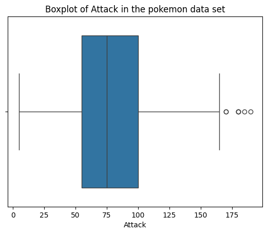

```python
# Boxplot of a numeric variable: Attack
snsplot = sns.boxplot(x='Attack', data = pokemon)
snsplot.set_title("Boxplot of Attack in the pokemon data set")
```

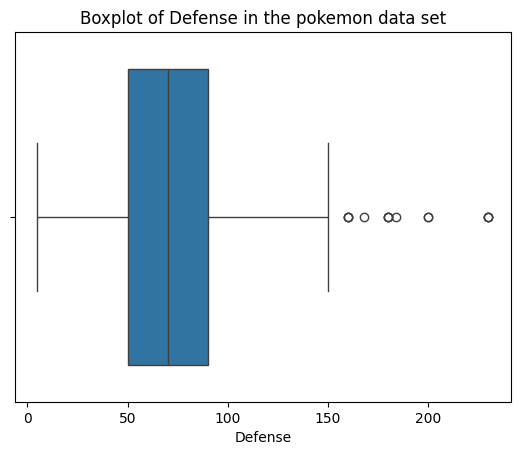

```python
# Boxplot of a numeric variable: Defense
snsplot = sns.boxplot(x='Defense', data = pokemon)
snsplot.set_title("Boxplot of Defense in the pokemon data set")
```

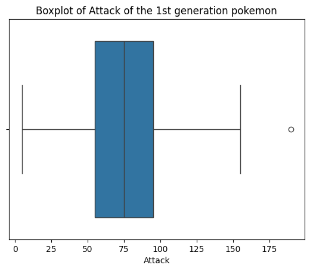

```python
# Boxplot of Attack of the 1st generation pokemon
snsplot = sns.boxplot(x='Attack', data = pokemon[pokemon['Generation']==1])
snsplot.set_title("Boxplot of Attack of the 1st generation pokemon")
```

[output not shown]

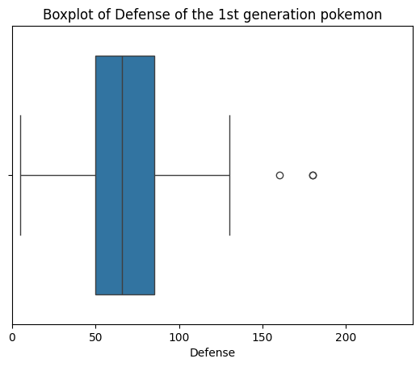

```python
# Boxplot of Defense of the 1st generation pokemon
snsplot = sns.boxplot(x='Defense', data = pokemon[pokemon['Generation']==1])
snsplot.set_title("Boxplot of Defense of the 1st generation pokemon")
snsplot.set_xlim([0, 240])
```

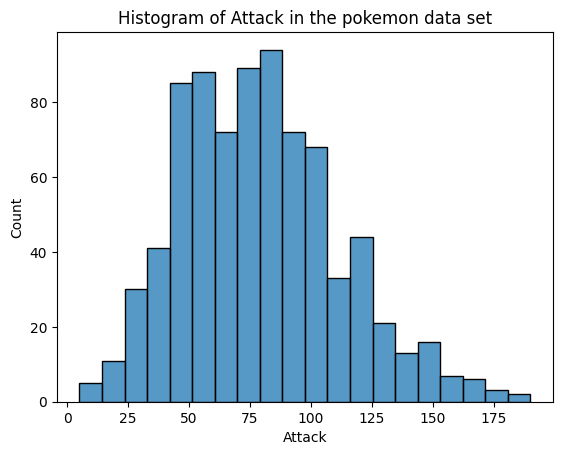

```python
# Histogram of a numeric variable: Attack
snsplot = sns.histplot(x='Attack', data = pokemon)
snsplot.set_title("Histogram of Attack in the pokemon data set")
```

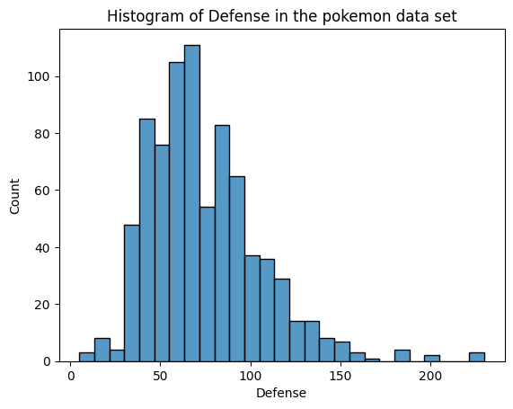

```python
# Histogram of a numeric variable: Defense
snsplot = sns.histplot(x='Defense', data = pokemon)
snsplot.set_title("Histogram of Defense in the pokemon data set")
```

### 3. Understanding a single variable: categorical variables

```python
# Show the statistics of a categorical variable: Type 1
pokemon['Type1'].describe()
```

```
count       800
unique       18
top       Water
freq        112
Name: Type1, dtype: object
```

```python
# Show the counts of unique pokemon types
pokemon['Type1'].value_counts()
```

```
Water       112
Normal       98
Grass        70
Bug          69
Psychic      57
Fire         52
Electric     44
Rock         44
Ghost        32
Ground       32
Dragon       32
Dark         31
Poison       28
Fighting     27
Steel        27
Ice          24
Fairy        17
Flying        4
Name: Type1, dtype: int64
```

```python
# Show the proportion of unique pokemon types
pokemon['Type1'].value_counts(normalize=True)
```

```
Water       0.14000
Normal      0.12250
Grass       0.08750
Bug         0.08625
Psychic     0.07125
Fire        0.06500
Electric    0.05500
Rock        0.05500
Ghost       0.04000
Ground      0.04000
Dragon      0.04000
Dark        0.03875
Poison      0.03500
Fighting    0.03375
Steel       0.03375
Ice         0.03000
Fairy       0.02125
Flying      0.00500
Name: Type1, dtype: float64
```

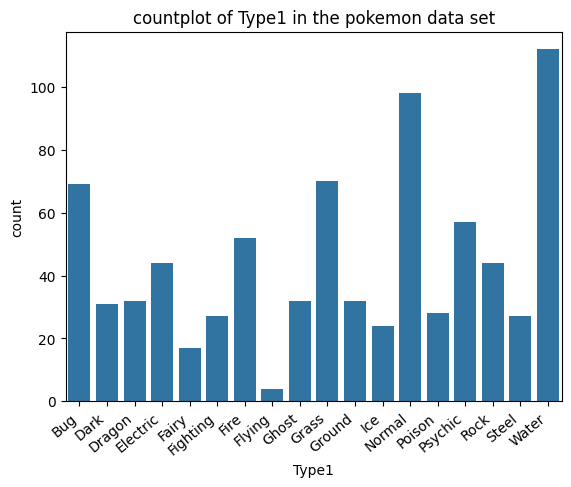

```python
# Plot a categorical variable: Type 1
snsplot = sns.countplot(x='Type1', data=pokemon)
snsplot.set_xticklabels(snsplot.get_xticklabels(), rotation=40, ha="right")
snsplot.set_title("countplot of Type1 in the pokemon data set")
```

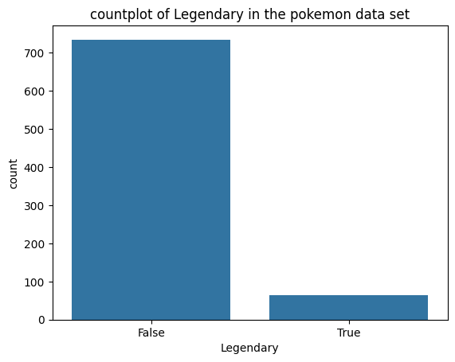

```python
# Plot a categorical variable: Legendary
snsplot = sns.countplot(x='Legendary', data=pokemon)
snsplot.set_title("countplot of Legendary in the pokemon data set")
```

### 4. Understand relationships of multiple variables

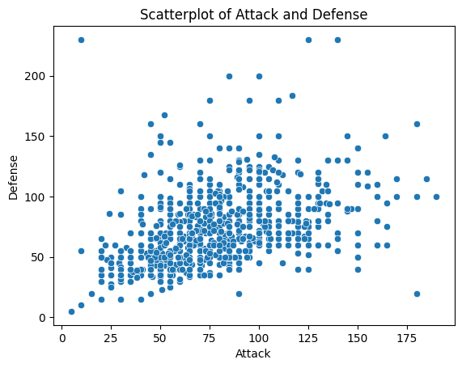

```python
# scatter plot two numeric variables: Attack and Defense
snsplot = sns.scatterplot(x='Attack', y= 'Defense', data=pokemon)
snsplot.set_title("Scatterplot of Attack and Defense")
```

```python
# Generate correlation coefficients of two numeric variables in a 2x2 matrix: Attack and Defense
# corr() lies between -1 and 1. zero means no correlation. 1 or -1 indicates full correlation
# positive value means positive correlation and negative values mean negative relationships
pokemon[['Attack','Defense']].corr()
```

|  | Attack | Defense |
| --- | --- | --- |
| Attack | 1.000000 | 0.438687 |
| Defense | 0.438687 | 1.000000 |

```python
# Generate the correlation matrix of all numeric variables
pokemon[['HP','Attack','Defense','SpAtk','SpDef','Speed']].corr()
pokemon.corr()
```

|  | HP | Attack | Defense | SpAtk | SpDef | Speed |
| --- | --- | --- | --- | --- | --- | --- |
| HP | 1.000000 | 0.422386 | 0.239622 | 0.362380 | 0.378718 | 0.175952 |
| Attack | 0.422386 | 1.000000 | 0.438687 | 0.396362 | 0.263990 | 0.381240 |
| Defense | 0.239622 | 0.438687 | 1.000000 | 0.223549 | 0.510747 | 0.015227 |
| SpAtk | 0.362380 | 0.396362 | 0.223549 | 1.000000 | 0.506121 | 0.473018 |
| SpDef | 0.378718 | 0.263990 | 0.510747 | 0.506121 | 1.000000 | 0.259133 |
| Speed | 0.175952 | 0.381240 | 0.015227 | 0.473018 | 0.259133 | 1.000000 |

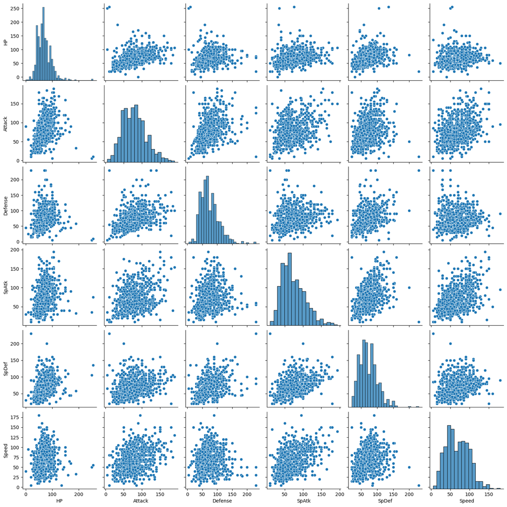

```python
# Generate 2D scatter plots
sns.pairplot(data = pokemon)
```

[output not shown]

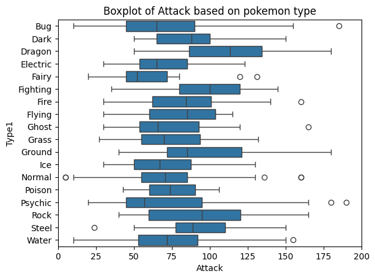

```python
# Examine relationships between numeric and categorical variables: boxplot groups values of a numeric variable based on the values of a categorical variable.
snsplot = sns.boxplot(x='Attack', y= 'Type1', data = pokemon)
snsplot.set_title("Boxplot of Attack based on pokemon type")
snsplot.set_xlim([0, 200])
```

```
(0.0, 200.0)
```

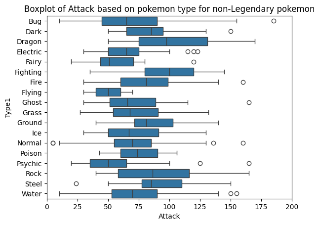

```python
snsplot = sns.boxplot(x='Attack', y= 'Type1', data = pokemon[pokemon['Legendary']==False])
snsplot.set_title("Boxplot of Attack based on pokemon type for non-Legendary pokemon")
snsplot.set_xlim([0, 200])
```

```
(0.0, 200.0)
```

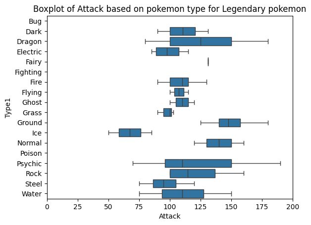

```python
snsplot = sns.boxplot(x='Attack', y= 'Type1', data = pokemon[pokemon['Legendary']==True])
snsplot.set_title("Boxplot of Attack based on pokemon type for Legendary pokemon")
snsplot.set_xlim([0, 200])
```

## Part 2: CarAuction Data

This dataset contains information of cars purchased at the Auction.  
SOME VARIABLE DESCRIPTIONS:  
Auction: Auction provider at which the vehicle was purchased  
Color: Vehicle Color  
IsBadBuy: Identifies if the kicked vehicle was an avoidable purchase  
MMRCurrentAuctionAveragePrice: Acquisition price for this vehicle in average condition as of current day  
Size: The size category of the vehicle (Compact, SUV, etc.)  
TopThreeAmericanName:Identifies if the manufacturer is one of the top three American manufacturers  
VehBCost: Acquisition cost paid for the vehicle at time of purchase  
VehicleAge: The Years elapsed since the manufacturer's year  
VehOdo: The vehicles odometer reading  
WarrantyCost: Warranty price (term=36month and millage=36K)  
WheelType: The vehicle wheel type description (Alloy, Covers)

### 1. Upload and clean data

```python
#Import packages
import pandas as pd
import seaborn as sns
```

```python
carAuction = pd.read_csv("/content/drive/MyDrive/IS670_Vishakha/car_kick.csv")
carAuction
```

|  | PurchDate | VehYear | VehicleAge | VehOdo | MMRAcquisitionAuctionAveragePrice | MMRAcquisitionAuctionCleanPrice | MMRAcquisitionRetailAveragePrice | MMRAcquisitonRetailCleanPrice | MMRCurrentAuctionAveragePrice | MMRCurrentAuctionCleanPrice | ... | WheelTypeID | WheelType | Nationality | Size | TopThreeAmericanName | BYRNO | VNZIP1 | VNST | IsOnlineSale | IsBadBuy |
| --- | --- | --- | --- | --- | --- | --- | --- | --- | --- | --- | --- | --- | --- | --- | --- | --- | --- | --- | --- | --- | --- |
| 0 | 1289952000 | 2006 | 4 | 51954 | 6197 | 7062 | 9605 | 10426 | 5341 | 6351 | ... | 2 | Covers | AMERICAN | MEDIUM | CHRYSLER | 99750 | 32124 | FL | 0 | 0 |
| 1 | 1242691200 | 2005 | 4 | 89127 | 3688 | 4783 | 4483 | 5666 | 3688 | 4783 | ... | 2 | Covers | AMERICAN | MEDIUM | FORD | 20833 | 78754 | TX | 0 | 0 |
| 2 | 1248220800 | 2006 | 3 | 71271 | 6897 | 8449 | 7949 | 9625 | 6868 | 8549 | ... | 1 | Alloy | AMERICAN | LARGE | GM | 22916 | 80011 | CO | 0 | 0 |
| 3 | 1285718400 | 2008 | 2 | 83338 | 7878 | 8925 | 11723 | 13026 | 7801 | 8704 | ... | 2 | Covers | AMERICAN | LARGE | GM | 23657 | 94544 | CA | 0 | 0 |
| 4 | 1237334400 | 2007 | 2 | 58698 | 8800 | 10091 | 10004 | 11398 | 7355 | 8543 | ... | 1 | Alloy | AMERICAN | LARGE | GM | 20833 | 77086 | TX | 0 | 0 |
| ... | ... | ... | ... | ... | ... | ... | ... | ... | ... | ... | ... | ... | ... | ... | ... | ... | ... | ... | ... | ... | ... |
| 67206 | 1285804800 | 2008 | 2 | 56072 | 6255 | 6972 | 9852 | 10567 | 6326 | 7126 | ... | 2 | Covers | AMERICAN | MEDIUM | CHRYSLER | 22808 | 77061 | TX | 0 | 1 |
| 67207 | 1274918400 | 2004 | 6 | 94232 | 8359 | 9645 | 12042 | 13302 | 7505 | 8188 | ... | 1 | Alloy | 'TOP LINE ASIAN' | 'MEDIUM SUV' | OTHER | 17675 | 28273 | NC | 0 | 1 |
| 67208 | 1280448000 | 2004 | 6 | 79534 | 2805 | 3826 | 6132 | 6871 | 3106 | 4479 | ... | 1 | Alloy | AMERICAN | MEDIUM | GM | 18880 | 37771 | TN | 0 | 1 |
| 67209 | 1285200000 | 2003 | 7 | 79394 | 4042 | 5296 | 7335 | 8983 | 3534 | 4732 | ... | 2 | Covers | AMERICAN | 'MEDIUM SUV' | GM | 23657 | 92337 | CA | 0 | 1 |
| 67210 | 1288742400 | 2004 | 6 | 94491 | 5194 | 6424 | 8532 | 9941 | 4417 | 5807 | ... | 1 | Alloy | 'OTHER ASIAN' | MEDIUM | OTHER | 835 | 87105 | NM | 0 | 1 |

67211 rows × 31 columns

```python
# Examine the number of rows and cols
carAuction.shape
```

```
(67211, 31)
```

```python
# Show the head rows of a data frame
carAuction.head()
```

|  | PurchDate | VehYear | VehicleAge | VehOdo | MMRAcquisitionAuctionAveragePrice | MMRAcquisitionAuctionCleanPrice | MMRAcquisitionRetailAveragePrice | MMRAcquisitonRetailCleanPrice | MMRCurrentAuctionAveragePrice | MMRCurrentAuctionCleanPrice | ... | WheelTypeID | WheelType | Nationality | Size | TopThreeAmericanName | BYRNO | VNZIP1 | VNST | IsOnlineSale | IsBadBuy |
| --- | --- | --- | --- | --- | --- | --- | --- | --- | --- | --- | --- | --- | --- | --- | --- | --- | --- | --- | --- | --- | --- |
| 0 | 1289952000 | 2006 | 4 | 51954 | 6197 | 7062 | 9605 | 10426 | 5341 | 6351 | ... | 2 | Covers | AMERICAN | MEDIUM | CHRYSLER | 99750 | 32124 | FL | 0 | 0 |
| 1 | 1242691200 | 2005 | 4 | 89127 | 3688 | 4783 | 4483 | 5666 | 3688 | 4783 | ... | 2 | Covers | AMERICAN | MEDIUM | FORD | 20833 | 78754 | TX | 0 | 0 |
| 2 | 1248220800 | 2006 | 3 | 71271 | 6897 | 8449 | 7949 | 9625 | 6868 | 8549 | ... | 1 | Alloy | AMERICAN | LARGE | GM | 22916 | 80011 | CO | 0 | 0 |
| 3 | 1285718400 | 2008 | 2 | 83338 | 7878 | 8925 | 11723 | 13026 | 7801 | 8704 | ... | 2 | Covers | AMERICAN | LARGE | GM | 23657 | 94544 | CA | 0 | 0 |
| 4 | 1237334400 | 2007 | 2 | 58698 | 8800 | 10091 | 10004 | 11398 | 7355 | 8543 | ... | 1 | Alloy | AMERICAN | LARGE | GM | 20833 | 77086 | TX | 0 | 0 |

5 rows × 31 columns

```python
# Examine missing values again
carAuction.isnull().sum()
```

```
PurchDate                            0
VehYear                              0
VehicleAge                           0
VehOdo                               0
MMRAcquisitionAuctionAveragePrice    0
MMRAcquisitionAuctionCleanPrice      0
MMRAcquisitionRetailAveragePrice     0
MMRAcquisitonRetailCleanPrice        0
MMRCurrentAuctionAveragePrice        0
MMRCurrentAuctionCleanPrice          0
MMRCurrentRetailAveragePrice         0
MMRCurrentRetailCleanPrice           0
VehBCost                             0
WarrantyCost                         0
Auction                              0
Make                                 0
Model                                0
Trim                                 0
SubModel                             0
Color                                0
Transmission                         0
WheelTypeID                          0
WheelType                            0
Nationality                          0
Size                                 0
TopThreeAmericanName                 0
BYRNO                                0
VNZIP1                               0
VNST                                 0
IsOnlineSale                         0
IsBadBuy                             0
dtype: int64
```

```python
# Examine variable type (0.5 pts)
carAuction.dtypes
```

[output not shown]

```python
# Change the following categorical variables to "category" (1 pt)
carAuction['Auction'] = carAuction['Auction'].astype('category')
carAuction['Color'] = carAuction['Color'].astype('category')
carAuction['IsBadBuy'] = carAuction['IsBadBuy'].astype('category')
carAuction['Size'] = carAuction['Size'].astype('category')
carAuction['TopThreeAmericanName'] = carAuction['TopThreeAmericanName'].astype('category')
carAuction['WheelType'] = carAuction['WheelType'].astype('category')
```

```python
# Display all numeric variables (0.5 pts)
carAuction.select_dtypes(include=['number'])
```

|  | PurchDate | VehYear | VehicleAge | VehOdo | MMRAcquisitionAuctionAveragePrice | MMRAcquisitionAuctionCleanPrice | MMRAcquisitionRetailAveragePrice | MMRAcquisitonRetailCleanPrice | MMRCurrentAuctionAveragePrice | MMRCurrentAuctionCleanPrice | MMRCurrentRetailAveragePrice | MMRCurrentRetailCleanPrice | VehBCost | WarrantyCost | WheelTypeID | BYRNO | VNZIP1 | IsOnlineSale |
| --- | --- | --- | --- | --- | --- | --- | --- | --- | --- | --- | --- | --- | --- | --- | --- | --- | --- | --- |
| 0 | 1289952000 | 2006 | 4 | 51954 | 6197 | 7062 | 9605 | 10426 | 5341 | 6351 | 8513 | 9822 | 6500 | 1086 | 2 | 99750 | 32124 | 0 |
| 1 | 1242691200 | 2005 | 4 | 89127 | 3688 | 4783 | 4483 | 5666 | 3688 | 4783 | 4483 | 5666 | 3680 | 983 | 2 | 20833 | 78754 | 0 |
| 2 | 1248220800 | 2006 | 3 | 71271 | 6897 | 8449 | 7949 | 9625 | 6868 | 8549 | 7917 | 9733 | 7170 | 1974 | 1 | 22916 | 80011 | 0 |
| 3 | 1285718400 | 2008 | 2 | 83338 | 7878 | 8925 | 11723 | 13026 | 7801 | 8704 | 11995 | 12901 | 7670 | 2152 | 2 | 23657 | 94544 | 0 |
| 4 | 1237334400 | 2007 | 2 | 58698 | 8800 | 10091 | 10004 | 11398 | 7355 | 8543 | 8443 | 9726 | 7165 | 1500 | 1 | 20833 | 77086 | 0 |
| ... | ... | ... | ... | ... | ... | ... | ... | ... | ... | ... | ... | ... | ... | ... | ... | ... | ... | ... |
| 67206 | 1285804800 | 2008 | 2 | 56072 | 6255 | 6972 | 9852 | 10567 | 6326 | 7126 | 9951 | 10806 | 6680 | 1086 | 2 | 22808 | 77061 | 0 |
| 67207 | 1274918400 | 2004 | 6 | 94232 | 8359 | 9645 | 12042 | 13302 | 7505 | 8188 | 10993 | 11655 | 8265 | 909 | 1 | 17675 | 28273 | 0 |
| 67208 | 1280448000 | 2004 | 6 | 79534 | 2805 | 3826 | 6132 | 6871 | 3106 | 4479 | 5981 | 7256 | 4950 | 1506 | 1 | 18880 | 37771 | 0 |
| 67209 | 1285200000 | 2003 | 7 | 79394 | 4042 | 5296 | 7335 | 8983 | 3534 | 4732 | 7165 | 8538 | 5220 | 3967 | 2 | 23657 | 92337 | 0 |
| 67210 | 1288742400 | 2004 | 6 | 94491 | 5194 | 6424 | 8532 | 9941 | 4417 | 5807 | 7814 | 9366 | 5890 | 1774 | 1 | 835 | 87105 | 0 |

67211 rows × 18 columns

```python
# Display all categorical variables (0.5 pts)
carAuction.select_dtypes(include=['category'])
```

|  | Auction | Color | WheelType | Size | TopThreeAmericanName | IsBadBuy |
| --- | --- | --- | --- | --- | --- | --- |
| 0 | MANHEIM | SILVER | Covers | MEDIUM | CHRYSLER | 0 |
| 1 | ADESA | SILVER | Covers | MEDIUM | FORD | 0 |
| 2 | MANHEIM | RED | Alloy | LARGE | GM | 0 |
| 3 | MANHEIM | BLACK | Covers | LARGE | GM | 0 |
| 4 | ADESA | WHITE | Alloy | LARGE | GM | 0 |
| ... | ... | ... | ... | ... | ... | ... |
| 67206 | MANHEIM | RED | Covers | MEDIUM | CHRYSLER | 1 |
| 67207 | ADESA | BLACK | Alloy | 'MEDIUM SUV' | OTHER | 1 |
| 67208 | ADESA | GOLD | Alloy | MEDIUM | GM | 1 |
| 67209 | MANHEIM | WHITE | Covers | 'MEDIUM SUV' | GM | 1 |
| 67210 | MANHEIM | RED | Alloy | MEDIUM | OTHER | 1 |

67211 rows × 6 columns

### 2. Understanding a single variable: numeric variables

```python
# Show the statistics of VehOdo (0.5 pts)
carAuction['VehOdo'].describe()
```

```
count     67211.000000
mean      71734.558971
std       14387.245482
min        5368.000000
25%       62163.000000
50%       73530.000000
75%       82530.000000
max      115717.000000
Name: VehOdo, dtype: float64
```

```python
# Obtain the variance, standard deviation, and range of WarrantyCost (0.5 pts)
print("variance: ", carAuction['WarrantyCost'].var(), "standard deviation: ", carAuction['WarrantyCost'].std(), "range: ", carAuction['WarrantyCost'].min(), carAuction['WarrantyCost'].max())
```

```
variance:  335331.0842767998 standard deviation:  579.0777877598136 range:  462 7498
```

```python
# Display the IQR of WarrantyCost (0.5 pts)
IQR = carAuction['WarrantyCost'].quantile(0.75) - carAuction['WarrantyCost'].quantile(0.25)
print("IQR:", IQR)
```

```
IQR: 770.0
```

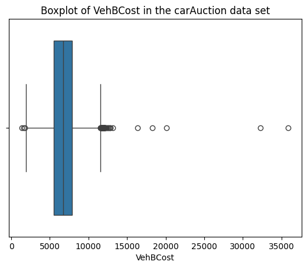

```python
# Boxplot of a numeric variable: VehBCost (0.5 pts)
snsplot = sns.boxplot(x='VehBCost', data = carAuction)
snsplot.set_title("Boxplot of VehBCost in the carAuction data set")
```

[figure not shown]

```python
# Boxplot of a numeric variable: VehicleAge (0.5 pts)
snsplot = sns.boxplot(x='VehicleAge', data = carAuction)
snsplot.set_title("Boxplot of VehBCost in the carAuction data set")
```

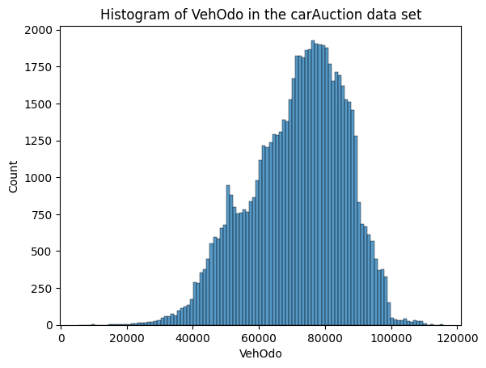

```python
# Histogram of a numeric variable: VehOdo (0.5 pts)
snsplot = sns.histplot(x='VehOdo', data = carAuction)
snsplot.set_title("Histogram of VehOdo in the carAuction data set")
```

### 3. Understanding a single variable: categorical variables

```python
# Display the number of cars in different WheelType (0.5 pts)
wheel_counts = carAuction['WheelType'].value_counts()
print(wheel_counts)
```

```
Alloy      34780
Covers     31701
Special      730
Name: WheelType, dtype: int64
```

```python
# Display the proportion of cars in different WheelType (0.5 pts)
wheel_proportions = carAuction['WheelType'].value_counts(normalize=True)
print(wheel_proportions)
```

```
Alloy      0.517475
Covers     0.471664
Special    0.010861
Name: WheelType, dtype: float64
```

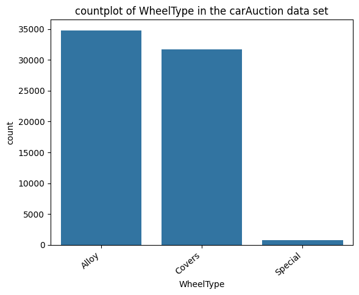

```python
# Plot a categorical variable: WheelType (0.5 pts)
snsplot = sns.countplot(x='WheelType', data=carAuction)
snsplot.set_xticklabels(snsplot.get_xticklabels(), rotation=40, ha="right")
snsplot.set_title("countplot of WheelType in the carAuction data set")
```

### 4. Understand relationships of multiple variables

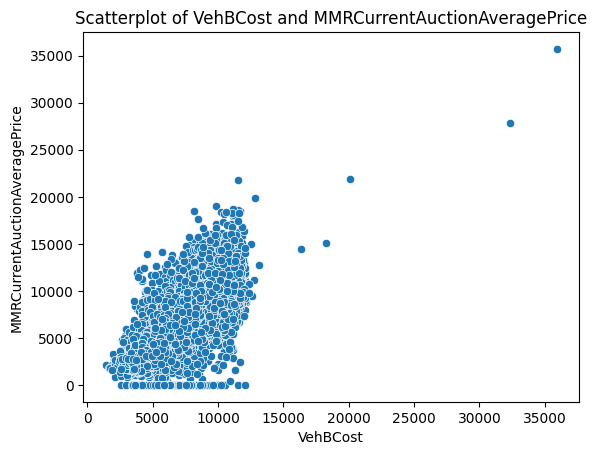

```python
# scatter plot two numeric variables: VehBCost and MMRCurrentAuctionAveragePrice (0.5 pts)
snsplot = sns.scatterplot(x='VehBCost', y= 'MMRCurrentAuctionAveragePrice', data=carAuction )
snsplot.set_title("Scatterplot of VehBCost and MMRCurrentAuctionAveragePrice")
```

```python
# Generate correlation coefficients of two numeric variables in a 2x2 matrix: VehBCost and MMRCurrentAuctionAveragePrice (0.5 pts)
carAuction[['VehBCost','MMRCurrentAuctionAveragePrice']].corr()
```

|  | VehBCost | MMRCurrentAuctionAveragePrice |
| --- | --- | --- |
| VehBCost | 1.000000 | 0.775695 |
| MMRCurrentAuctionAveragePrice | 0.775695 | 1.000000 |

```python
# Generate the correlation matrix of all numeric variables (0.5 pts)
carAuction['PurchDate','VehYear','VehicleAge','VehOdo','MMRAcquisitionAuctionAveragePrice','MMRAcquisitionAuctionCleanPrice','MMRAcquisitionRetailAveragePrice','MMRAcquisitonRetailCleanPrice','MMRCurrentAuctionAveragePrice',	'MMRCurrentAuctionCleanPrice',	'MMRCurrentRetailAveragePrice',	'MMRCurrentRetailCleanPrice',	'VehBCost',	'WarrantyCost',	'WheelTypeID',	'BYRNO','VNZIP1',	'IsOnlineSale'].corr()
carAuction.corr()
```

[output not shown]

```python
# Examine relationships between numeric and categorical variables: boxplot VehBCost based on IsBadBuy (0.5 pts)
```

[output not shown]

```python
!jupyter nbconvert --to html "/content/drive/MyDrive/Colab Notebooks/IS670_lab02.ipynb"
```

```
[NbConvertApp] Converting notebook /content/drive/MyDrive/Colab Notebooks/IS670_lab02.ipynb to html
[NbConvertApp] Writing 1918386 bytes to /content/drive/MyDrive/Colab Notebooks/IS670_lab02.html
```